# Выбор региона добычи нефти

Проект на синтетических данных. Добывающей компании необходимо определить наиболее выгодный регион для нефтедобычи.

**Задача**: определить регион, где нефтедобыча принесёт наибольшую прибыль. Для этого с помощью модели машинного обучения выбрать наиболее выгодные месторождения и проанализировать возможную прибыль и риски с помощью техники *Bootstrap.*

**Условия:**

- При разведке региона исследуют 500 точек, из которых с помощью машинного обучения выбирают 200 лучших для разработки.
- Бюджет на разработку скважин в регионе — 10 млрд рублей.
- Доход с каждой единицы продукта составляет 450 тыс. рублей (450 руб/баррель), поскольку объём указан в тысячах баррелей.
- Для разработки подходят лишь те регионы, где вероятность убытков меньше 2.5%.

**Описание шагов при выборе локации:**

- В избранном регионе собирают характеристики для скважин: качество нефти и объём её запасов;
- Строят модель для предсказания объёма запасов в новых скважинах;
- Выбирают месторождения с самым высокими оценками значений. Количество месторождений зависит от бюджета компании и стоимости разработки одной скважины;
- Определяют регион с максимальной суммарной прибылью отобранных скважин (прибыль равна суммарной прибыли отобранных месторождений).

**Описание данных:**  
Исторические данные о пробах нефти из трёх регионов. В каждом регионе 100 000 месторождений, где измерили качество нефти и объём её запасов в каждом месторождении.

- id — уникальный идентификатор скважины;
- f0, f1, f2 — признаки качетва, неизвестно, что они означают, но признаки значимы;
- product — объём запасов в скважине, тыс баррелей.

# Содержание

```python
# !pip install phik
```

```python
# import libraries
import os
import warnings
warnings.filterwarnings('ignore')

import matplotlib.pyplot as plt
import numpy as np
import pandas as pd
import seaborn as sns

from sklearn.linear_model import LinearRegression
from sklearn.metrics import mean_squared_error
from sklearn.model_selection import train_test_split
from sklearn.preprocessing import StandardScaler

from phik.report import correlation_report, plot_correlation_matrix
```

```python
# display settings
pd.options.display.max_columns = None
pd.set_option('display.max_colwidth', 100)
pd.set_option("display.precision", 4)

%matplotlib inline
```

## Обзор и подготовка данных

Имеются данные из трех регионов, создадим функцию для чтения файлов и вывода основной информации по ним.

```python
# data path
path = os.path.join(os.path.dirname(os.getcwd()), '8_MLinBusiness')
```

```python
# define function to read files and display information about the data
def read_file(path, filename):
    """ Функция принимает путь к файлу и строку -
    наазвание датасета.
    Читает данные, выводит основную информацию
    по файлу, возвращает датафрейм с данными"""

    # reading files
    try:
        df = pd.read_csv(os.path.join(path, filename))
    except:
        df = pd.read_csv('/datasets/'+filename)

    # get first and last 5 rows
    display(df)

    # get information about the data
    print()
    print(df.info())

    # check for duplicates
    print()
    if df.duplicated().sum() > 0:
        print('В данных есть явные дубликаты')
    else:
        print('В данных нет явных дубликатов')

    # check for NaN
    if df.isna().sum().sum() > 0:
        print('В данных есть пропущенные значения')
    else:
        print('В данных нет пропущенных значений')

    return df
```

Загрузим данные, для этого создадим список датафреймов.

```python
# create list of dataframes
N_REGIONS = 3

data = []
for i in range(N_REGIONS):
    print(f'РЕГИОН {i+1}')
    filename = 'geo_data_'+f'{i}.csv'
    df = read_file(path, filename)
    print()

    # add dataframe to the list of dataframes
    data.append(df)
```

```
РЕГИОН 1
```

|  | id | f0 | f1 | f2 | product |
| --- | --- | --- | --- | --- | --- |
| 0 | txEyH | 0.7057 | -0.4978 | 1.2212 | 105.2801 |
| 1 | 2acmU | 1.3347 | -0.3402 | 4.3651 | 73.0378 |
| 2 | 409Wp | 1.0227 | 0.1520 | 1.4199 | 85.2656 |
| 3 | iJLyR | -0.0322 | 0.1390 | 2.9786 | 168.6208 |
| 4 | Xdl7t | 1.9884 | 0.1554 | 4.7518 | 154.0366 |
| ... | ... | ... | ... | ... | ... |
| 99995 | DLsed | 0.9720 | 0.3710 | 6.0753 | 110.7440 |
| 99996 | QKivN | 1.3924 | -0.3826 | 1.2739 | 122.3468 |
| 99997 | 3rnvd | 1.0296 | 0.0188 | -1.3483 | 64.3754 |
| 99998 | 7kl59 | 0.9982 | -0.5286 | 1.5839 | 74.0408 |
| 99999 | 1CWhH | 1.7648 | -0.2664 | 5.7228 | 149.6332 |

100000 rows × 5 columns

```
<class 'pandas.core.frame.DataFrame'>
RangeIndex: 100000 entries, 0 to 99999
Data columns (total 5 columns):
 #   Column   Non-Null Count   Dtype
---  ------   --------------   -----
 0   id       100000 non-null  object
 1   f0       100000 non-null  float64
 2   f1       100000 non-null  float64
 3   f2       100000 non-null  float64
 4   product  100000 non-null  float64
dtypes: float64(4), object(1)
memory usage: 3.8+ MB
None

В данных нет явных дубликатов
В данных нет пропущенных значений

РЕГИОН 2
```

|  | id | f0 | f1 | f2 | product |
| --- | --- | --- | --- | --- | --- |
| 0 | kBEdx | -15.0013 | -8.2760 | -0.0059 | 3.1791 |
| 1 | 62mP7 | 14.2721 | -3.4751 | 0.9992 | 26.9533 |
| 2 | vyE1P | 6.2632 | -5.9484 | 5.0012 | 134.7663 |
| 3 | KcrkZ | -13.0812 | -11.5061 | 4.9994 | 137.9454 |
| 4 | AHL4O | 12.7022 | -8.1474 | 5.0044 | 134.7663 |
| ... | ... | ... | ... | ... | ... |
| 99995 | QywKC | 9.5356 | -6.8781 | 1.9983 | 53.9065 |
| 99996 | ptvty | -10.1606 | -12.5581 | 5.0056 | 137.9454 |
| 99997 | 09gWa | -7.3789 | -3.0841 | 4.9987 | 137.9454 |
| 99998 | rqwUm | 0.6657 | -6.1526 | 1.0001 | 30.1324 |
| 99999 | relB0 | -3.4261 | -7.7943 | -0.0033 | 3.1791 |

100000 rows × 5 columns

```
<class 'pandas.core.frame.DataFrame'>
RangeIndex: 100000 entries, 0 to 99999
Data columns (total 5 columns):
 #   Column   Non-Null Count   Dtype
---  ------   --------------   -----
 0   id       100000 non-null  object
 1   f0       100000 non-null  float64
 2   f1       100000 non-null  float64
 3   f2       100000 non-null  float64
 4   product  100000 non-null  float64
dtypes: float64(4), object(1)
memory usage: 3.8+ MB
None

В данных нет явных дубликатов
В данных нет пропущенных значений

РЕГИОН 3
```

|  | id | f0 | f1 | f2 | product |
| --- | --- | --- | --- | --- | --- |
| 0 | fwXo0 | -1.1470 | 0.9633 | -0.8290 | 27.7587 |
| 1 | WJtFt | 0.2628 | 0.2698 | -2.5302 | 56.0697 |
| 2 | ovLUW | 0.1946 | 0.2890 | -5.5864 | 62.8719 |
| 3 | q6cA6 | 2.2361 | -0.5538 | 0.9300 | 114.5728 |
| 4 | WPMUX | -0.5160 | 1.7163 | 5.8990 | 149.6007 |
| ... | ... | ... | ... | ... | ... |
| 99995 | 4GxBu | -1.7770 | 1.1252 | 6.2634 | 172.3270 |
| 99996 | YKFjq | -1.2615 | -0.8948 | 2.5245 | 138.7488 |
| 99997 | tKPY3 | -1.1999 | -2.9576 | 5.2194 | 157.0801 |
| 99998 | nmxp2 | -2.4199 | 2.4172 | -5.5484 | 51.7953 |
| 99999 | V9kWn | -2.5514 | -2.0256 | 6.0909 | 102.7758 |

100000 rows × 5 columns

```
<class 'pandas.core.frame.DataFrame'>
RangeIndex: 100000 entries, 0 to 99999
Data columns (total 5 columns):
 #   Column   Non-Null Count   Dtype
---  ------   --------------   -----
 0   id       100000 non-null  object
 1   f0       100000 non-null  float64
 2   f1       100000 non-null  float64
 3   f2       100000 non-null  float64
 4   product  100000 non-null  float64
dtypes: float64(4), object(1)
memory usage: 3.8+ MB
None

В данных нет явных дубликатов
В данных нет пропущенных значений
```

Проверим, повторяются ли скважины в регионах.

```python
# number of unique wells
print('Количество уникальных скважин:')
for i in range(N_REGIONS):
    print(f'В Регионе {i+1}: {len(data[i].id.unique())} из 100000')
```

```
Количество уникальных скважин:
В Регионе 1: 99990 из 100000
В Регионе 2: 99996 из 100000
В Регионе 3: 99996 из 100000
```

В каждом регионе в данных есть повторы id скважин. Посмотрим на значения характеристик в этих скважинах.

```python
# повторяющиеся скважины для каждого региона
for i in range(N_REGIONS):
    # mask for duplicated wells
    dupl = (data[i].id
            .value_counts()
            .index[data[i].id.value_counts() > 1])
    print(f'Повторяющиеся скважины в Регионе {i+1}')
    display(data[i][data[i].id.isin(dupl)]
            .sort_values(by='id'))
    print()
```

```
Повторяющиеся скважины в Регионе 1
```

|  | id | f0 | f1 | f2 | product |
| --- | --- | --- | --- | --- | --- |
| 66136 | 74z30 | 1.0850 | -0.3124 | 6.9908 | 127.6433 |
| 64022 | 74z30 | 0.7415 | 0.4592 | 5.1531 | 140.7715 |
| 51970 | A5aEY | -0.1803 | 0.9355 | -2.0948 | 33.0202 |
| 3389 | A5aEY | -0.0399 | 0.1569 | 0.2099 | 89.2494 |
| 69163 | AGS9W | -0.9338 | 0.1162 | -3.6559 | 19.2305 |
| 42529 | AGS9W | 1.4547 | -0.4797 | 0.6834 | 126.3705 |
| 931 | HZww2 | 0.7553 | 0.3685 | 1.8632 | 30.6818 |
| 7530 | HZww2 | 1.0612 | -0.3740 | 10.4302 | 158.8287 |
| 63593 | QcMuo | 0.6356 | -0.4734 | 0.8627 | 64.5787 |
| 1949 | QcMuo | 0.5066 | -0.3238 | -2.2156 | 75.4965 |
| 75715 | Tdehs | 0.1121 | 0.4303 | 3.2190 | 60.9640 |
| 21426 | Tdehs | 0.8294 | 0.2988 | -0.0496 | 96.0353 |
| 92341 | TtcGQ | 0.1107 | 1.0227 | 0.9114 | 101.3180 |
| 60140 | TtcGQ | 0.5693 | -0.1049 | 6.4402 | 85.3502 |
| 89582 | bsk9y | 0.3989 | -0.4003 | 10.1224 | 163.4331 |
| 97785 | bsk9y | 0.3784 | 0.0058 | 0.1608 | 160.6373 |
| 41724 | bxg6G | -0.8238 | 0.5463 | 3.6305 | 93.0078 |
| 1364 | bxg6G | 0.4116 | 0.8568 | -3.6534 | 73.6043 |
| 16633 | fiKDv | 0.1573 | 1.0284 | 5.5856 | 95.8179 |
| 90815 | fiKDv | 0.0499 | 0.8413 | 6.3946 | 137.3466 |

```
Повторяющиеся скважины в Регионе 2
```

|  | id | f0 | f1 | f2 | product |
| --- | --- | --- | --- | --- | --- |
| 5849 | 5ltQ6 | -3.4354 | -12.2960 | 1.9998 | 57.0856 |
| 84461 | 5ltQ6 | 18.2138 | 2.1920 | 3.9939 | 107.8130 |
| 1305 | LHZR0 | 11.1708 | -1.9451 | 3.0029 | 80.8598 |
| 41906 | LHZR0 | -8.9897 | -4.2866 | 2.0091 | 57.0856 |
| 2721 | bfPNe | -9.4944 | -5.4637 | 4.0060 | 110.9921 |
| 82178 | bfPNe | -6.2028 | -4.8200 | 2.9951 | 84.0389 |
| 47591 | wt4Uk | -9.0911 | -8.1093 | -0.0023 | 3.1791 |
| 82873 | wt4Uk | 10.2600 | -9.3764 | 4.9943 | 134.7663 |

```
Повторяющиеся скважины в Регионе 3
```

|  | id | f0 | f1 | f2 | product |
| --- | --- | --- | --- | --- | --- |
| 45404 | KUPhW | 0.2318 | -1.6989 | 4.9908 | 11.7163 |
| 55967 | KUPhW | 1.2112 | 3.1764 | 5.5435 | 132.8318 |
| 11449 | VF7Jo | 2.1227 | -0.8583 | 5.7460 | 181.7168 |
| 49564 | VF7Jo | -0.8831 | 0.5605 | 0.7236 | 136.2334 |
| 44378 | Vcm5J | -1.2295 | -2.4392 | 1.2229 | 137.9683 |
| 95090 | Vcm5J | 2.5877 | 1.9869 | 2.4822 | 92.3276 |
| 28039 | xCHr8 | 1.6330 | 0.3681 | -2.3784 | 6.1205 |
| 43233 | xCHr8 | -0.8471 | 2.1018 | 5.5971 | 184.3886 |

**Вывод:**  
В каждом из трех регионов, где ведется нефтедобыча, имеется 100 000 скважин, с различными характеристиками нефти и объемом запасов. В данных нет пропусков и явных дубликатов, но информация по некоторым скважинам дана два раза и отличается - у скважин одинаковые id, но совершенно разные характеристики. Оставим эти данные, возможно, была сделана ошибка в id скважины.

## Исследовательский анализ данных

### Характеристики качества нефти и ее запасов в каждом регионе

Для каждого региона посмотрим на распределения значений и описательную статистику характеричтик качества нефти `f0`, `f1`, `f2` и ее запасов `product`.

```
РЕГИОН 1
```

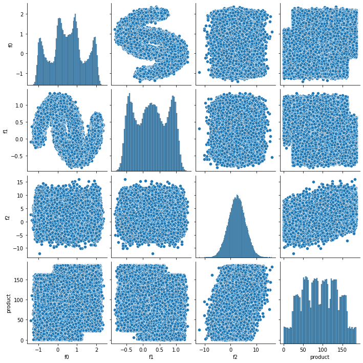

```
РЕГИОН 2
```

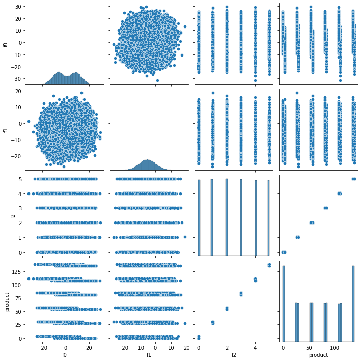

```
РЕГИОН 3
```

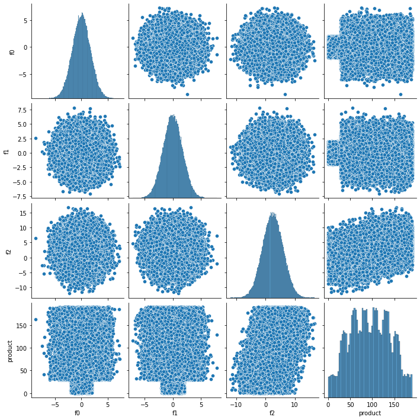

```python
# scatterplots and distribution histograms for each region
for i in range(N_REGIONS):
    print(f'РЕГИОН {i+1}')
    sns.pairplot(data[i])
    plt.show()
```

```python
# descriptive statistics for each region
for i in range(N_REGIONS):
    print(f'РЕГИОН {i+1}')
    display(data[i].describe())
    print(f"Общий объем запасов {data[i]['product'].sum() / 1000000:.2f} млн баррелей")
    print()
```

```
РЕГИОН 1
```

|  | f0 | f1 | f2 | product |
| --- | --- | --- | --- | --- |
| count | 100000.0000 | 100000.0000 | 100000.0000 | 100000.0000 |
| mean | 0.5004 | 0.2501 | 2.5026 | 92.5000 |
| std | 0.8718 | 0.5044 | 3.2482 | 44.2887 |
| min | -1.4086 | -0.8482 | -12.0883 | 0.0000 |
| 25% | -0.0726 | -0.2009 | 0.2877 | 56.4975 |
| 50% | 0.5024 | 0.2503 | 2.5160 | 91.8500 |
| 75% | 1.0736 | 0.7006 | 4.7151 | 128.5641 |
| max | 2.3623 | 1.3438 | 16.0038 | 185.3643 |

```
Общий объем запасов 9.25 млн баррелей

РЕГИОН 2
```

|  | f0 | f1 | f2 | product |
| --- | --- | --- | --- | --- |
| count | 100000.0000 | 100000.0000 | 100000.0000 | 100000.0000 |
| mean | 1.1413 | -4.7966 | 2.4945 | 68.8250 |
| std | 8.9659 | 5.1199 | 1.7036 | 45.9444 |
| min | -31.6096 | -26.3586 | -0.0181 | 0.0000 |
| 25% | -6.2986 | -8.2680 | 1.0000 | 26.9533 |
| 50% | 1.1531 | -4.8132 | 2.0115 | 57.0856 |
| 75% | 8.6210 | -1.3328 | 3.9999 | 107.8130 |
| max | 29.4218 | 18.7341 | 5.0197 | 137.9454 |

```
Общий объем запасов 6.88 млн баррелей

РЕГИОН 3
```

|  | f0 | f1 | f2 | product |
| --- | --- | --- | --- | --- |
| count | 100000.0000 | 100000.0000 | 100000.0000 | 100000.0000 |
| mean | 0.0020 | -0.0021 | 2.4951 | 95.0000 |
| std | 1.7320 | 1.7304 | 3.4734 | 44.7499 |
| min | -8.7600 | -7.0840 | -11.9703 | 0.0000 |
| 25% | -1.1623 | -1.1748 | 0.1304 | 59.4504 |
| 50% | 0.0094 | -0.0095 | 2.4842 | 94.9256 |
| 75% | 1.1585 | 1.1637 | 4.8588 | 130.5950 |
| max | 7.2383 | 7.8448 | 16.7394 | 190.0298 |

```
Общий объем запасов 9.50 млн баррелей
```

**Вывод**:  
Видно, что характеристики нефти и ее запасы достаточно отличаются в зависимости от региона. Самое бедное месторождение во 2 регионе - около 7 млн баррелей во всех скважинах, а вот в 1 и 3 регионах общий объем больше - более 9 млн. Отдельные скважины также более бедные во втором регионе - в среднем около 70 тыс баррелей в каждой, для большинства скважин объем нефти не превышает 108 тыс. баррелей, а четверть имеет меньше 28. В 1 и 3 регионах показатели лучше - три четверти скважин имеет запас более 55 тыс баррелей, а в среднем запасы каждой скважине составляют более 90 тыс баррелей.  
Значения характеристик нефти очень отличаются между регионами - возможно, используются разные шкалы.  
Второй регион выделяется по распределению признаков. Здесь запасы нефти в скважинах линейно зависят от `f2`. Значения этого признака и объемов нефти дискретны, что может быть связано с особенностями снятия показаний в регионе. Стоит отметить, что и для других регионов наблюдаются пики в количестве скважин для определенных запасов нефти (схожие с дискретными значениями во втором регионе): около 30, 60, 80, 110 и 130 тыс. баррелей.

Судя из статистики по регионам, может показаться, что разработка новых месторождений более выгодна в регионах с более богатыми месторождениями нефти. Однако прогноз количества сырья по его качеству (значению признаков `f0-2`) может быть надежнее совершенно в другом регионе. Так, для второго региона видна четкая линейная связь признака `f2` с объемом нефти в скважинах. Чем признак `f2` больше, тем больше запас. В 1 и 3 регионах зависимость также прослеживается, хоть и не такая выраженная. С оставшимися двумя признаками связь сложнее, она нелинейная и различается для регионов. Так, в первом регионе для самых больших значений признака `f0` объем запасов всегда выше 20 тыс. баррелей, а для самых низких - никогда не выше 160. Для `f1` - наоборот, для самых низких значений объем запасов всегда выше 20 тыс. баррелей, а для самых высоких - никогда не выше 160. Видно, что эти признаки нелинейно взаимосвязаны друг с другом. В 3 регионе в бедных скважинах с объемом нефти до 25 тыс баррелей разброс значений признаков `f0` и `f1` намного уже, чем в более богатых скважинах. Во втором регионе также есть некоторая связь значений признака `f0` с объемом нефти в скважине: для каждой группы скважин с определенным диапазоном объема запасов нефти есть как бы два кластера значений признака, в кластере более высоких значений признака объем нефти внутри каждого диапазона будет чуть ниже.

### Взаимодействие признаков

Посмотрим, подтвердит ли корреляцинный анализ предположение о связи переменных. Поскольку были видны нелинейные взяимосвязи между переменными, используем коэффициенты корреляции Phi_k.

```
РЕГИОН 1
interval columns not set, guessing: ['f0', 'f1', 'f2', 'product']
```

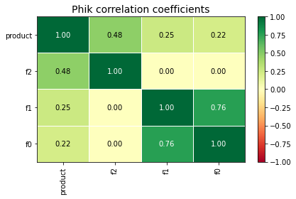

```
РЕГИОН 2
interval columns not set, guessing: ['f0', 'f1', 'f2', 'product']
```

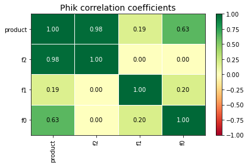

```
РЕГИОН 3
interval columns not set, guessing: ['f0', 'f1', 'f2', 'product']
```

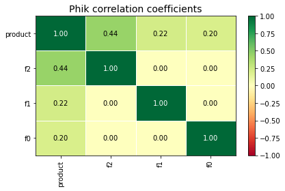

```python
# Phik correlation coefficients matrix
for i in range(N_REGIONS):
    print(f'РЕГИОН {i+1}')
    phik_overview = data[i].drop(['id'], axis=1).phik_matrix()
    plot_correlation_matrix(phik_overview.values,
                            x_labels=phik_overview.columns,
                            y_labels=phik_overview.index,
                            title="Phik correlation coefficients",
                            figsize=(6, 4))
    plt.show()
```

**Вывод:**  
Как было видно из диаграмм рассеивания - наибольшая корреляция объемов запаса нефти в скважинах наблюдается с признаком `f2`, во втором регионе значение достигает 0.98 (0.48 и 0.44 для 1 и 3 регионов соответсвенно). С признаками `f0` и `f1` объем нефти в скважине связан не сильно, корреляция около 0.2; только во 2 регионе для `f0` эта корреляция составила 0.63.  
Сильная взаимная корреляция между признаками не наблюдается, только в 1 регионе `f0` сильно взаимосвязан с `f1` (корреляция 0.76), что мы и видели на диаграммах рассеивания.

## Построение модели

### Подготовка данных

#### Разделение датасетов

- Выделение целевой переменной

```python
# targets and features for 3 regions
Y = []
X = []
for i in range(N_REGIONS):
    y = data[i]['product']
    x = data[i].drop(['id', 'product'], axis=1)

    # add dataframes to the lists of targets and features
    Y.append(y)
    X.append(x)
    print(f'РЕГИОН {i+1}')
    print(f'Features {X[i].shape}')
    display(X[i].head(3))
    print(f'Target {Y[i].shape}')
    print()
```

```
РЕГИОН 1
Features (100000, 3)
```

|  | f0 | f1 | f2 |
| --- | --- | --- | --- |
| 0 | 0.7057 | -0.4978 | 1.2212 |
| 1 | 1.3347 | -0.3402 | 4.3651 |
| 2 | 1.0227 | 0.1520 | 1.4199 |

```
Target (100000,)

РЕГИОН 2
Features (100000, 3)
```

|  | f0 | f1 | f2 |
| --- | --- | --- | --- |
| 0 | -15.0013 | -8.2760 | -0.0059 |
| 1 | 14.2721 | -3.4751 | 0.9992 |
| 2 | 6.2632 | -5.9484 | 5.0012 |

```
Target (100000,)

РЕГИОН 3
Features (100000, 3)
```

|  | f0 | f1 | f2 |
| --- | --- | --- | --- |
| 0 | -1.1470 | 0.9633 | -0.8290 |
| 1 | 0.2628 | 0.2698 | -2.5302 |
| 2 | 0.1946 | 0.2890 | -5.5864 |

```
Target (100000,)
```

- Разделение на обучающую (75%) и валидационную (25%) выборки

```python
X_train = []
X_valid = []
Y_train = []
Y_valid = []

for i in range(N_REGIONS):
    # Splitting dataset into train and test set
    x_train, x_valid, y_train, y_valid = train_test_split(
        X[i], Y[i], test_size=0.25, random_state=123)
    print(f'РЕГИОН {i+1}')
    print(x_train.shape, x_valid.shape, y_train.shape, y_valid.shape)

    # add dataframe to the lists of datasets for train and validation
    X_train.append(x_train)
    X_valid.append(x_valid)
    Y_train.append(y_train)
    Y_valid.append(y_valid)
```

```
РЕГИОН 1
(75000, 3) (25000, 3) (75000,) (25000,)
РЕГИОН 2
(75000, 3) (25000, 3) (75000,) (25000,)
РЕГИОН 3
(75000, 3) (25000, 3) (75000,) (25000,)
```

#### Масштабирование признаков

Одни и те же ризнаки в данных очень разного масштаба. Для линейных моделей лучше использовать масштабированные данные.

```python
X_train_scl = []
X_valid_scl = []

for i in range(N_REGIONS):
    # Creating the scaler
    scaler = StandardScaler()
    # Fit the scaler on the training data
    scaler.fit(X_train[i])

    # Rescaling the training data
    x_train_scl = scaler.transform(X_train[i])
    # Rescaling the validation data
    x_valid_scl = scaler.transform(X_valid[i])

    # add dataframes to the lists of scaled datasets
    X_train_scl.append(x_train_scl)
    X_valid_scl.append(x_valid_scl)

    # Mean and SD of scaled data
    print(f'РЕГИОН {i+1}')
    print('Данные для обучения')
    display(pd.DataFrame(
        X_train_scl[i]).describe().loc[['mean', 'std']])
    print()
    print('Данные для валидации')
    display(pd.DataFrame(
        X_valid_scl[i]).describe().loc[['mean', 'std']])
    print()
```

```
РЕГИОН 1
Данные для обучения
```

|  | 0 | 1 | 2 |
| --- | --- | --- | --- |
| mean | 2.5787e-17 | 3.8319e-17 | 8.1715e-17 |
| std | 1.0000e+00 | 1.0000e+00 | 1.0000e+00 |

```
Данные для валидации
```

|  | 0 | 1 | 2 |
| --- | --- | --- | --- |
| mean | 0.0086 | -0.0098 | 0.0032 |
| std | 1.0006 | 1.0032 | 1.0073 |

```
РЕГИОН 2
Данные для обучения
```

|  | 0 | 1 | 2 |
| --- | --- | --- | --- |
| mean | 2.8771e-17 | 6.7703e-17 | -1.1387e-16 |
| std | 1.0000e+00 | 1.0000e+00 | 1.0000e+00 |

```
Данные для валидации
```

|  | 0 | 1 | 2 |
| --- | --- | --- | --- |
| mean | 0.0121 | 0.0032 | 0.0135 |
| std | 0.9981 | 1.0020 | 0.9967 |

```
РЕГИОН 3
Данные для обучения
```

|  | 0 | 1 | 2 |
| --- | --- | --- | --- |
| mean | -2.4188e-18 | -4.0212e-17 | 5.2539e-17 |
| std | 1.0000e+00 | 1.0000e+00 | 1.0000e+00 |

```
Данные для валидации
```

|  | 0 | 1 | 2 |
| --- | --- | --- | --- |
| mean | 0.0113 | 0.0073 | 0.0029 |
| std | 1.0054 | 0.9987 | 1.0059 |

### Обучение модели

Для предсказания значений объема нефти в скважинах на основе характеристик ее качества используем модель линейной регрессии. Сохраним модели для каждого региона в список.

```python
models = []
for i in range(N_REGIONS):
    # Creating the model
    model = LinearRegression()
    # Fitting the model on the training data
    model.fit(X_train_scl[i], Y_train[i])
    models.append(model)
```

```python
# Prediction on training set
Y_train_pred = []

for i in range(N_REGIONS):
    y_train_pred = models[i].predict(X_train_scl[i])
    Y_train_pred.append(y_train_pred)
```

```python
# Prediction on validation set
Y_valid_pred = []

for i in range(N_REGIONS):
    y_valid_pred = models[i].predict(X_valid_scl[i])
    Y_valid_pred.append(y_valid_pred)
```

```python
# Constant model (mean)
Y_const_pred = []

for i in range(N_REGIONS):
    y_const_pred = [Y_train[i].mean()] * len(Y_valid[i])
    Y_const_pred.append(y_const_pred)
```

```python
# Evaluation of the models
prod_preds_mean = []

for i in range(N_REGIONS):
    # mean of the predicted production
    prod_pred_mean = Y_valid_pred[i].mean()
    prod_preds_mean.append(prod_pred_mean)

    # RMSE
    rmse_valid = mean_squared_error(Y_valid[i], Y_valid_pred[i])**0.5
    rmse_train = mean_squared_error(Y_train[i], Y_train_pred[i])**0.5
    rmse_const = mean_squared_error(Y_valid[i], Y_const_pred[i])**0.5

    print(f'РЕГИОН {i+1}')
    print(f'Cредний предсказанный запас сырья {prod_pred_mean:.2f}')
    print(f'RMSE модели на валидационной выборке {rmse_valid:.2f}')
    print(f'RMSE модели на обучающей выборке {rmse_train:.2f}')
    print(f'RMSE константной модели {rmse_const:.2f}')
    print()
```

```
РЕГИОН 1
Cредний предсказанный запас сырья 92.55
RMSE модели на валидационной выборке 37.65
RMSE модели на обучающей выборке 37.71
RMSE константной модели 44.41

РЕГИОН 2
Cредний предсказанный запас сырья 69.28
RMSE модели на валидационной выборке 0.90
RMSE модели на обучающей выборке 0.89
RMSE константной модели 45.82

РЕГИОН 3
Cредний предсказанный запас сырья 95.10
RMSE модели на валидационной выборке 40.13
RMSE модели на обучающей выборке 40.03
RMSE константной модели 44.67
```

Отобразим значения коэффициентов моделей, "важность" признаков, для каждого региона.

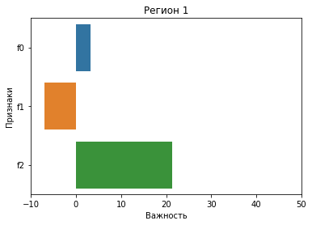

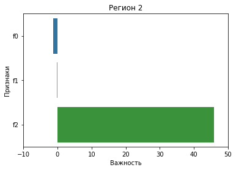

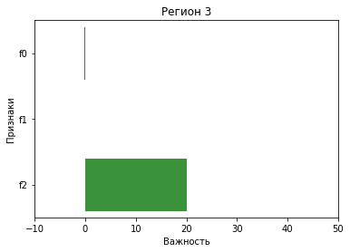

```python
# Barplots for coefficients of linear regression models
for i in range(N_REGIONS):
    sns.barplot(x=models[i].coef_, y=['f0', 'f1', 'f2'])
    plt.title(f'Регион {i+1}')
    plt.xlim(-10, 50)
    plt.xlabel('Важность')
    plt.ylabel('Признаки')
    plt.show()
```

**Вывод:**  
Средний предсказанный объем сырья в скважинах во всех регионах схож со средними реальными значениям каждого региона. Модели для всех регионов предсказывают лучше, чем константные модели. Наиболее точные предсказания у модели для второго региона - в среднем она ошибается примерно лишь на одну тысячу баррелей на каждом объекте. В регионах 1 и 3 метрика RMSE значительно хуже, модели в среднем ошибаются примерно на 40 тысяч баррелей на каждом объекте.  
Как и предполагалось, признак `f2` имеет наибольшее влияние на целевую переменную.

## Расчёт прибыли и рисков

Из описания проекта известно, что при разведке региона исследуют 500 новых точек, из которых с помощью машинного обучения выбирают 200 лучших для разработки, основываясь на признаках месторождений. Бюджет на разработку новых скважин составляет 10 млрд рублей. Баррель нефти стоит 450 рублей, что составляет 450 тыс рублей на каждую единицу продукта (тк объём указан в тысячах баррелей).

Чтобы окупились затраты на разработку 200 скважин, необходимо, чтобы количества сырья в них при существующих ценах на нефть было для этого достаточно. Рассчитаем достаточный средний объём сырья в скважинах для безубыточной разработки и сравним со средним запасом в скважинах в каждом регионе.

```python
# Well development budget, rub
BUDGET = 10000000000

# Number of wells for exploration
N_WELLS = 500

# Number of best wells to develop
N_BEST_WELLS = 200

# oil price, rub per 1000 barrels
OIL_PRICE = 450000
```

```python
# Volume of "ideal" well, for break-even development
prod_ideal = np.ceil(BUDGET / (N_BEST_WELLS * OIL_PRICE))
print('Объём сырья в скважине для безубыточной разработки, тыс баррелей:')
print(prod_ideal)
```

```
Объём сырья в скважине для безубыточной разработки, тыс баррелей:
112.0
```

Посмотрим, какое количество скважин в каждом регионе отвечает "идеальному" значению объема.

```python
print(f'Процент скважин с объемом >= {prod_ideal} тыс баррелей:')
for i in range(N_REGIONS):
    print(f'РЕГИОН {i+1}')
    print(f'{len(data[i].query("product >= 112"))/len(data[i]):.0%}')
```

```
Процент скважин с объемом >= 112.0 тыс баррелей:
РЕГИОН 1
36%
РЕГИОН 2
17%
РЕГИОН 3
37%
```

**Вывод:**  
Чтобы не понести убытков после разработки новых скважин, средний объем нефти в скважинах при указанной цене за сырье должен быть около 112 тысяч баррелей. Ни в одном регионе нет такого среднего показателя, хотя скважины с запасом нефти 112 тыс баррелей и более имеются везде и достаточно. Это говорит о необходимости более качественного прогноза для разработки новых скважин и более точного выбора на его основе новых скважин для разработки.

**Оценим риски и прибыль для каждого региона**.  
Мы предполагаем, что распределение запасов в скважинах в каждом из регионов такое же, как в наших данных. По условию мы знаем, что в каждом регионе есть 500 новых скважин, для которых у нас есть прогноз запаса нефти. Для того, чтобы понять, какое распределение прибыли можно ожидать для каждого региона - применим технику *Bootstrap*, для каждого региона выберем 1000 раз рандомно 500 скважин. Каждый раз выберем из них для разработки 200 лучших по количеству предсказанного запаса нефти (моделирование ситуации, что нам неизвестно, сколько нефти реально в этих скважинах). Для каждой выборки посчитаем вероятную прибыль от этих 200 месторождений, используя уже реальные значения объема запасов (моделирование ситуации, что мы уже знаем, сколько нефти было добато из скважин).

Сначала напишем функцию для подсчета прибыли.

```python
# define function to calculate profit
def profit(df, n):
    """ Функция получает на вход датафрейм со значениями
    объемов сырья в скважинах в тыс. баррелей ('target')
    и предсказаниями этих объемов моделью ('prediction');
    а также необходимое количество скважин ('n').
    Функция возвращает выручку - прибыль от n
    наиболее прибыльных скважин.
    """
    # sort wells by predicted product and take first n wells
    best_prod = df.sort_values(by='prediction', ascending=False)[:n]

    # calculate profit
    prft = best_prod['target'].sum() * OIL_PRICE - BUDGET

    # calculate profit
    return prft
```

Получим расперделение прибыли, которую мы можем получить в каждом регионе.

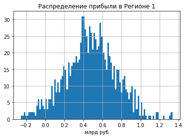

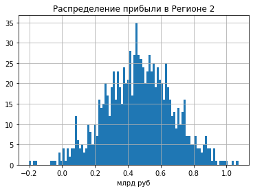

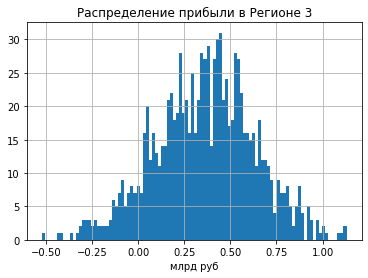

```python
# profit distributions for all regions
profit_distrbs = []

state = np.random.RandomState(123)

for i in range(N_REGIONS):
    # make dataframe from product and product prediction
    # from validation dataset
    target_prediction = pd.DataFrame({'target': Y_valid[i],
                                      'prediction': Y_valid_pred[i]})

    # choose 1000 times 500 random wells
    profit_distrb = []
    N = 1000
    for j in range(N):
        # 500 random wells
        target_prediction_sub = target_prediction.sample(
            N_WELLS, replace=True, random_state=state)
        #calculate profit for 200 best wells
        proft = profit(target_prediction_sub, N_BEST_WELLS)
        profit_distrb.append(proft)

    profit_distrb = pd.Series(profit_distrb)

    # add profit distribution of each region
    profit_distrbs.append(profit_distrb)

    # Distribution histograms for each region
    (profit_distrbs[i] / 1000000000).hist(bins=100)
    plt.title(f'Распределение прибыли в Регионе {i+1}')
    plt.xlabel('млрд руб')
    plt.show()
```

Найдем среднюю прибыль для каждого региона, 95%-й доверительный интервал и риск убытков (отрицательная прибыль). По условиям задачи, разработку можно проводить только в тех регионах, где вероятность убытков меньше 2.5%.

```python
for i in range(N_REGIONS):
    profit_lower = profit_distrbs[i].quantile(0.025)
    profit_upper = profit_distrbs[i].quantile(0.975)
    profit_mean = profit_distrbs[i].mean()

    print(f'Регион {i+1}')
    print(f'Средняя прибыль, млрд руб: {profit_mean/1000000000:0.3f}')
    print(f'95%-доверительный интервал: {profit_lower/(1000000000):0.3f} - {profit_upper/(1000000000):0.3f}')
    print(f'Вероятность убытков: {(profit_distrbs[i] <= 0).mean():.2%}')
    print()
```

```
Регион 1
Средняя прибыль, млрд руб: 0.477
95%-доверительный интервал: -0.058 - 0.975
Вероятность убытков: 4.10%

Регион 2
Средняя прибыль, млрд руб: 0.467
95%-доверительный интервал: 0.069 - 0.871
Вероятность убытков: 1.00%

Регион 3
Средняя прибыль, млрд руб: 0.362
95%-доверительный интервал: -0.183 - 0.871
Вероятность убытков: 8.90%
```